# Lab 7

STA 206 | Fall 2021

November 8, 2020

In this lab, we will explore a data set about diabetes. This data consist of 19 variables on 403 subjects who were interviewed in a study to understand the prevalence of obesity, diabetes, and other risk factors in central Virginia for African Americans. According to Dr John Hong, Diabetes Mellitus Type II (adult onset diabetes) is associated most strongly with obesity. The waist/hip ratio may be a predictor in diabetes and heart disease. DM II is also associated with hypertension.

### Read Data

```r
diabetes = read.table('diabetes.txt', header=TRUE)
```

```r
sapply(diabetes,class) # find out what types of variables you have
```

```
##          id        chol    stab.glu         hdl       ratio       glyhb
##   "integer"   "integer"   "integer"   "integer"   "numeric"   "numeric"
##    location         age      gender      height      weight       frame
## "character"   "integer" "character"   "integer"   "integer" "character"
##       bp.1s       bp.1d       bp.2s       bp.2d       waist         hip
##   "integer"   "integer"   "integer"   "integer"   "integer"   "integer"
##    time.ppn
##   "integer"
```

Note that even though some of the variables are categorical, their class are indicated as “character” instead of “factor”. Such variables in this case are `location`, `gender`, `frame`. So, we need to convert them to factors first.

```r
diabetes$location <- as.factor(diabetes$location)
diabetes$gender <- as.factor(diabetes$gender)
diabetes$frame <- as.factor(diabetes$frame)

sapply(diabetes,class)
```

```
##        id      chol  stab.glu       hdl     ratio     glyhb  location       age
## "integer" "integer" "integer" "integer" "numeric" "numeric"  "factor" "integer"
##    gender    height    weight     frame     bp.1s     bp.1d     bp.2s     bp.2d
##  "factor" "integer" "integer"  "factor" "integer" "integer" "integer" "integer"
##     waist       hip  time.ppn
## "integer" "integer" "integer"
```

### Deal with Categorical Variables (Factors)

Suppose we are interested in exploring a categorical variable from the diabetes data. Let’s take a look at `frame`. To check how many levels `frame` has, and what their names are:

```r
levels(diabetes$frame)
```

```
## [1] ""       "large"  "medium" "small"
```

R tells us that there are 4 levels, but one of them is without a label (missing value). We can check which observations have the " " label, and then we can use the `table` function to get counts of each factor level:

```r
which(diabetes$frame=='')
```

```
##  [1]  51  64  70 109 111 153 225 283 328 333 349 381
```

```r
table(diabetes$frame)
```

```
##
##         large medium  small
##     12    103    184    104
```

So 12 cases have a missing value for frame; 103 have the class “large”, etc.

Next, we can use this table to create a bar chart and a pie chart.

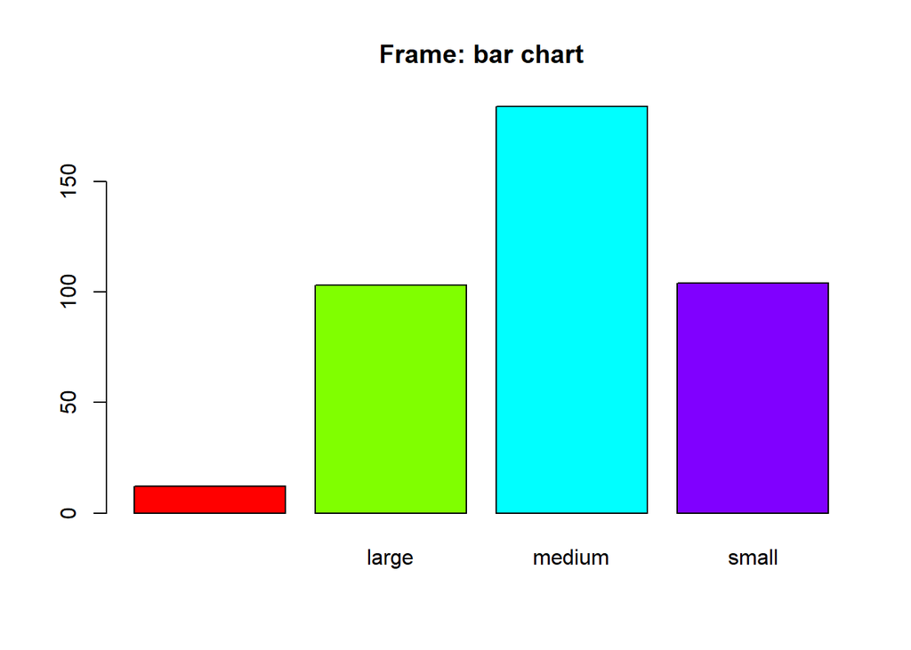

```r
### bar chart
barplot(table(diabetes$frame),col=rainbow(4),main='Frame: bar chart')
```

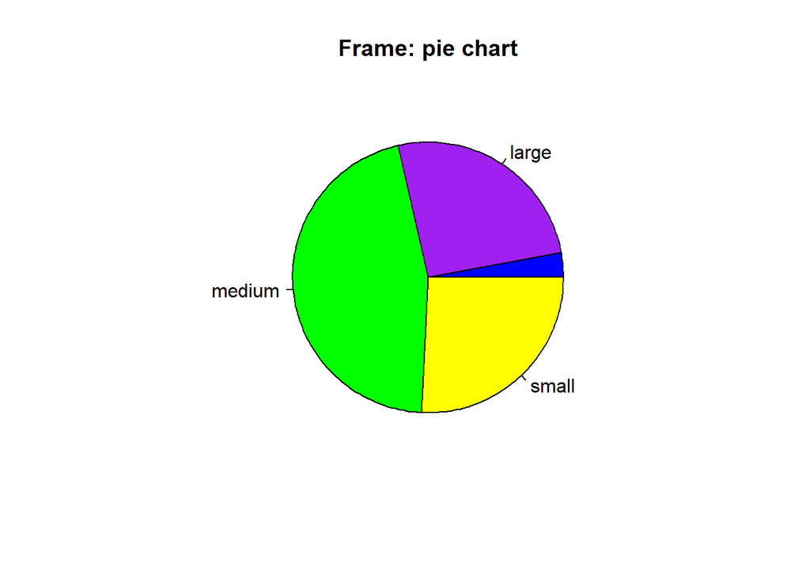

```r
### pie chart without percentages
pie(table(diabetes$frame),col=c('blue','purple','green','yellow'),
main='Frame: pie chart')
```

If you want to annotate the percentages in the pie chart, follow this:

```r
### pie chart with percentages

n <- nrow(diabetes)
lbls <- c('NA','large','medium','small')
pct <- round(100*table(diabetes$frame)/n)
lab <- paste(lbls,pct)
lab <- paste(lab,'%',sep='')
lab
```

```
## [1] "NA 3%"      "large 26%"  "medium 46%" "small 26%"
```

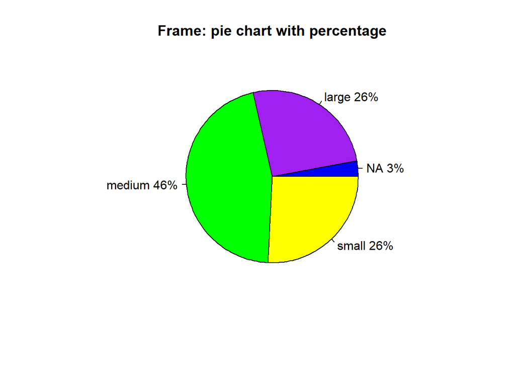

```r
pie(table(diabetes$frame),labels=lab,col=c('blue','purple','green','yellow'),
main='Frame: pie chart with percentage')
```

We also might be interested in, say, how the `cholesterol` levels are distributed for the different `frame` levels. For this we might use side-by-side boxplots:

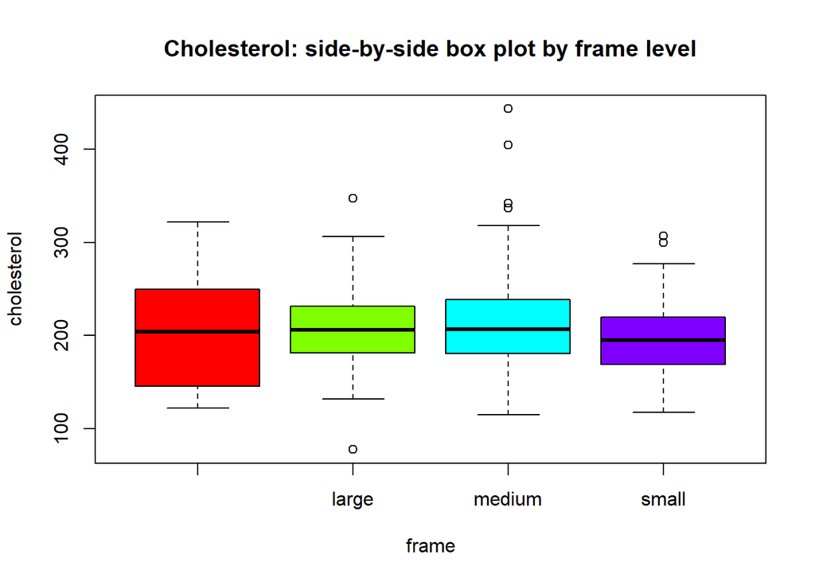

```r
boxplot(diabetes$chol~diabetes$frame,main='Cholesterol: side-by-side box plot by frame level',
xlab='frame',ylab='cholesterol',col=rainbow(4))
```

### Manually Specify Dummy Variables

When we quantify a categorical variable with $r$ factor levels (classes), we use $r-1$ indicators, or dummy variables. You have seen in class that if a categorical variable only has 2 factor levels, then we only need one dummy variable. Here is how we can do this manually in R:

```r
n <- nrow(diabetes)# n is the sample size
indicator <- rep(0,n) # start with a vector of 0's

indicator[which(diabetes$gender=='male')] <- 1 # replace male entries with 1
head(indicator)
```

```
## [1] 0 0 0 1 1 1
```

```r
head(diabetes$gender)
```

```
## [1] female female female male   male   male
## Levels: female male
```

Notice that the dummy variable matches with the gender variable. Now let’s go back to the `frame` example. Here we have 3 different factor levels, so we are going to need 2 dummy variables. For the purposes of illustration, we will remove the observations where frame = " ", but we will see how to deal with the missing values in the next section.

```r
no.na=diabetes$frame[diabetes$frame != ''] # remove frame=''
length(no.na) # get the new size
```

```
## [1] 391
```

```r
small <- rep(0,391) # start with 0's
small[which(no.na=='small')] <- 1 # replace with 1's
med <- rep(0,391)
med[which(no.na=='medium')] <- 1
head(cbind(small,med))
```

```
##      small med
## [1,]     0   1
## [2,]     0   0
## [3,]     0   0
## [4,]     0   0
## [5,]     0   1
## [6,]     0   0
```

### Deal with Missing Values (NA) in Regression

Not all data is complete. In this section we explore how we can deal with missing values using R. Here are some basic functions for dealing with NAs:

```r
summary(diabetes$bp.1s)
```

```
##    Min. 1st Qu.  Median    Mean 3rd Qu.    Max.    NA's
##    90.0   121.2   136.0   136.9   146.8   250.0       5
```

```r
is.na(diabetes$bp.1s)[1:10]
```

```
##  [1] FALSE FALSE FALSE FALSE FALSE FALSE FALSE  TRUE FALSE FALSE
```

Notice that if we take the summary of the variable `bp.1s`, it tells us how many missing values there are. To R, NA is a distinct value that it can interpret. There might arise some occasions where your data does not have NA for missing values, but rather something like ’ ’ or ‘.’. In these cases it would be a good idea to replace those values with the standard NA that R can recognize. In our case, this problem arises with the `frame` variable:

```r
summary(diabetes$frame)
```

```
##         large medium  small
##     12    103    184    104
```

```r
which(diabetes$frame=='') # shows observation # of NA's
```

```
##  [1]  51  64  70 109 111 153 225 283 328 333 349 381
```

```r
is.na(diabetes$frame) <- which(diabetes$frame=='') # replaces '' with NA
diabetes$frame <- droplevels(diabetes$frame) # takes away the old class ''
summary(diabetes$frame)
```

```
##  large medium  small   NA's
##    103    184    104     12
```

Some functions in R don’t work nicely with missing values. For instance, the mean function will return NA even if only 1 of the observations is missing. In this case, you can avoid the problem using the option `na.rm`, which ignores NA’s in the data:

```r
mean(diabetes$bp.1s)
```

```
## [1] NA
```

```r
mean(diabetes$bp.1s,na.rm=TRUE)
```

```
## [1] 136.9045
```

While fitting the regression model, for missing values, we have two options using the `na.action` argument in the `lm` function. If we choose `na.exclude`, R doesn’t use the missing values, but keeps their position for residuals and fitted values. If we choose `na.omit` (this is the default), R removes the missing value observations completely from the analysis. These can be shown by example:

```r
fit1 = lm(weight ~ waist + hip + height+ age, data=diabetes) ##default is na.omit
length(residuals(fit1)) # less than the total number of subjects in the data, which is 403
```

```
## [1] 395
```

```r
summary(residuals(fit1)) # no NA's
```

```
##     Min.  1st Qu.   Median     Mean  3rd Qu.     Max.
## -45.7191  -9.1799  -0.4353   0.0000   9.4072  51.5733
```

```r
fit1$na.action
```

```
##  64  87 162 196 232 318 337 394
##  64  87 162 196 232 318 337 394
## attr(,"class")
## [1] "omit"
```

```r
fit2 = lm(weight ~ waist + hip + height+ age, na.action=na.exclude, data=diabetes)
length(residuals(fit2)) # residual for every case in the data; For those with missing values, NA is returned
```

```
## [1] 403
```

```r
summary(residuals(fit2)) # some NA's
```

```
##     Min.  1st Qu.   Median     Mean  3rd Qu.     Max.     NA's
## -45.7191  -9.1799  -0.4353   0.0000   9.4072  51.5733        8
```

```r
fit2$na.action
```

```
##  64  87 162 196 232 318 337 394
##  64  87 162 196 232 318 337 394
## attr(,"class")
## [1] "exclude"
```

Finally, there is another commonly used method of dealing with missing values for quantitative (predictor) variables. Here we replace the missing value by the mean of the non-missing values of that variable:

```r
summary(diabetes$bp.1s) # NA's
```

```
##    Min. 1st Qu.  Median    Mean 3rd Qu.    Max.    NA's
##    90.0   121.2   136.0   136.9   146.8   250.0       5
```

```r
diabetes$bp.1s[is.na(diabetes$bp.1s)] <- mean(diabetes$bp.1s,na.rm=TRUE)#computes mean removing NA
summary(diabetes$bp.1s) # no NA's
```

```
##    Min. 1st Qu.  Median    Mean 3rd Qu.    Max.
##    90.0   122.0   136.0   136.9   146.0   250.0
```

Note that filling NA’s by sample mean does not change the mean of the variable. This should only be done for the predictor variables and we **do not** do this for the response variable since it is what we are trying to model. There are many potential problems with this naive imputation method. For example, it can cause bias (e.g., when missing is not at random), so be cautious.

## Regression with Categorical Variables

In some data sets, a categorical variable may be coded numerically (how it is coded is usually provided in the document accompanying the data). If the three classes of `frame` had been coded as 1- small 2- medium 3-large, then we would need to treat it as a categorical variable and explicitly use `factor(frame)` in the `lm` function, as well as with the `pairs` function. In such a situation, had we simply used `frame`, then it would be treated as a quantitative variable (because its values are numeric now, even though those values are only allocated codes for the three classes) and give misleading results.

Let’s try a simple example using `weight` as the response variable with predictors `height` and `gender`. To make a scatter plot colored by `gender`:

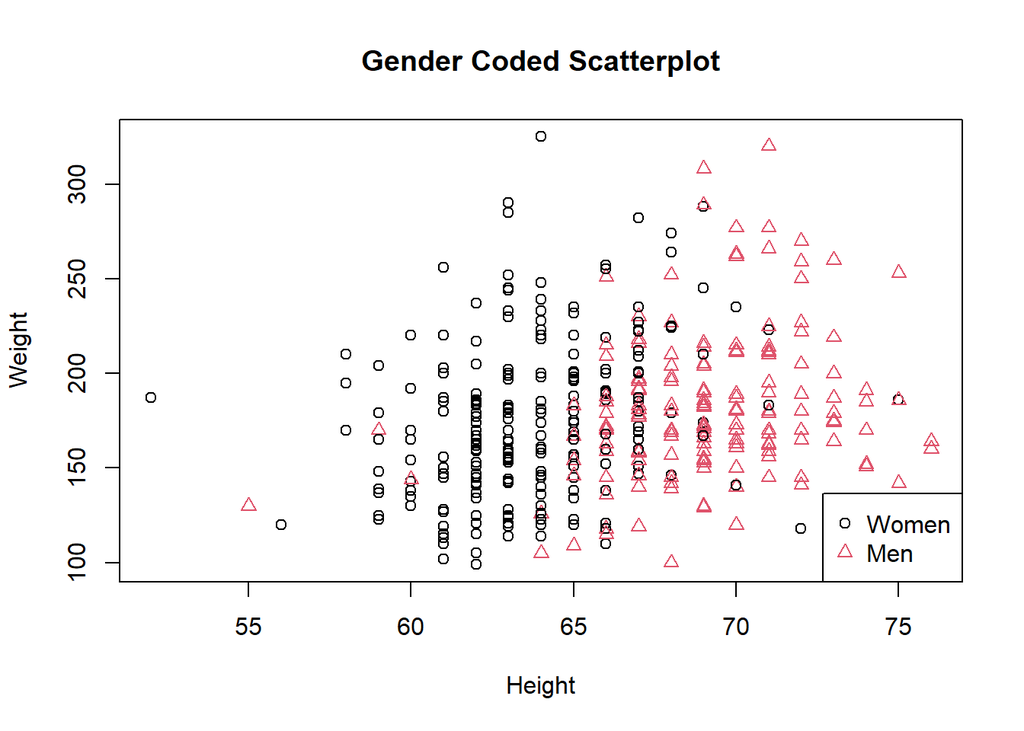

```r
plot(diabetes$height,diabetes$weight,pch=as.integer(diabetes$gender),
      col=as.integer(diabetes$gender),main='Gender Coded Scatterplot',
        ylab='Weight',xlab='Height')
legend('bottomright',legend=c('Women','Men'),
        pch=c(1,2),col=c(1,2)) # add a legend
```

Now let’s fit the first-order model and get the coefficients so that we can draw the respective regression lines onto the scatter plot:

```r
weight.fit <- lm(weight~height+gender, data=diabetes)
summary(weight.fit)
```

```
##
## Call:
## lm(formula = weight ~ height + gender, data = diabetes)
##
## Residuals:
##     Min      1Q  Median      3Q     Max
## -86.976 -26.407  -5.352  21.840 149.309
##
## Coefficients:
##             Estimate Std. Error t value Pr(>|t|)
## (Intercept) -58.5847    43.4091  -1.350   0.1779
## height        3.6606     0.6799   5.384 1.25e-07 ***
## gendermale  -12.5132     5.3885  -2.322   0.0207 *
## ---
## Signif. codes:  0 '***' 0.001 '**' 0.01 '*' 0.05 '.' 0.1 ' ' 1
##
## Residual standard error: 38.92 on 394 degrees of freedom
##   (6 observations deleted due to missingness)
## Multiple R-squared:  0.07578,    Adjusted R-squared:  0.07109
## F-statistic: 16.15 on 2 and 394 DF,  p-value: 1.812e-07
```

```r
# Or, if you prefer your model with coefficient for both levels and without intercept
weight.fit.1 <- lm(weight~height+gender-1, data=diabetes)
summary(weight.fit.1)
```

```
##
## Call:
## lm(formula = weight ~ height + gender - 1, data = diabetes)
##
## Residuals:
##     Min      1Q  Median      3Q     Max
## -86.976 -26.407  -5.352  21.840 149.309
##
## Coefficients:
##              Estimate Std. Error t value Pr(>|t|)
## height         3.6606     0.6799   5.384 1.25e-07 ***
## genderfemale -58.5847    43.4091  -1.350    0.178
## gendermale   -71.0978    47.0903  -1.510    0.132
## ---
## Signif. codes:  0 '***' 0.001 '**' 0.01 '*' 0.05 '.' 0.1 ' ' 1
##
## Residual standard error: 38.92 on 394 degrees of freedom
##   (6 observations deleted due to missingness)
## Multiple R-squared:  0.9548, Adjusted R-squared:  0.9544
## F-statistic:  2772 on 3 and 394 DF,  p-value: < 2.2e-16
```

From the summary, we see that the regression line for the female group (the default reference level due to the alphabetical order) has intercept $-58.58$ with a slope of $3.66$, while the regression line for the male group has intercept $-58.58-12.51=-71.09$ with the same slope as the female regression line as there is no interaction in this model. We can add lines to our plot using the `abline` function:

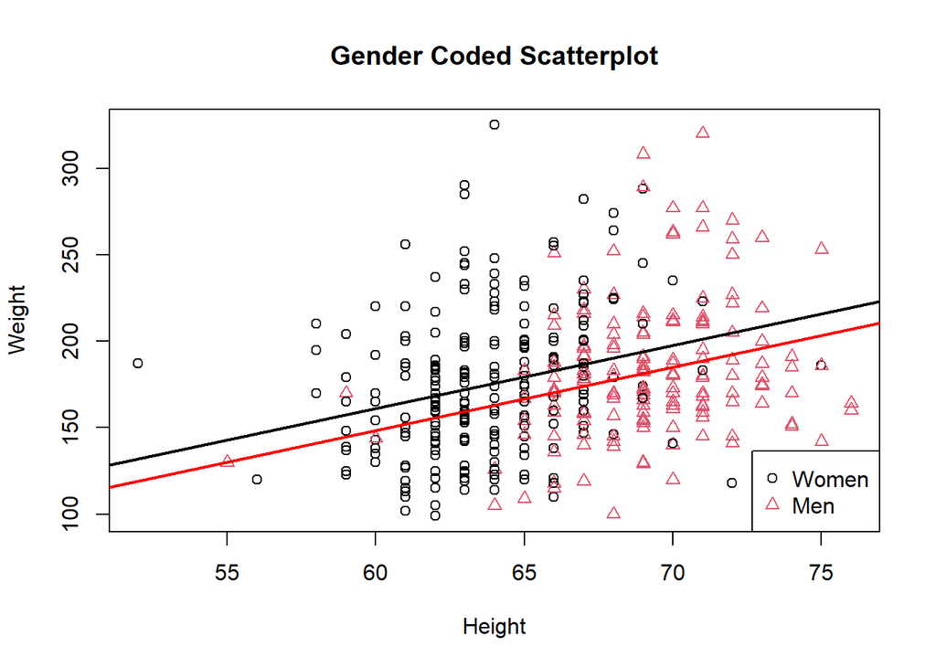

```r
af <- weight.fit$coefficients[1]
am <- weight.fit$coefficients[1]+weight.fit$coefficients[3]
bf = bm = weight.fit$coefficients[2]

plot(diabetes$height,diabetes$weight,pch=as.integer(diabetes$gender),
      col=as.integer(diabetes$gender),main='Gender Coded Scatterplot',
        ylab='Weight',xlab='Height')
legend('bottomright',legend=c('Women','Men'),
        pch=c(1,2),col=c(1,2)) # add a legend
abline(af,bf,col=1,lwd=2)
abline(am,bm,col='red',lwd=2)
```

Now suppose we’d like to make male instead of female as our reference level. We need to specify the reference level by the function `relevel`:

```r
weight.fit2 <- lm(weight~height+relevel(gender, ref="male"),  data=diabetes)
summary(weight.fit2)
```

```
##
## Call:
## lm(formula = weight ~ height + relevel(gender, ref = "male"),
##     data = diabetes)
##
## Residuals:
##     Min      1Q  Median      3Q     Max
## -86.976 -26.407  -5.352  21.840 149.309
##
## Coefficients:
##                                     Estimate Std. Error t value Pr(>|t|)
## (Intercept)                         -71.0978    47.0903  -1.510   0.1319
## height                                3.6606     0.6799   5.384 1.25e-07 ***
## relevel(gender, ref = "male")female  12.5132     5.3885   2.322   0.0207 *
## ---
## Signif. codes:  0 '***' 0.001 '**' 0.01 '*' 0.05 '.' 0.1 ' ' 1
##
## Residual standard error: 38.92 on 394 degrees of freedom
##   (6 observations deleted due to missingness)
## Multiple R-squared:  0.07578,    Adjusted R-squared:  0.07109
## F-statistic: 16.15 on 2 and 394 DF,  p-value: 1.812e-07
```

From the summary, we see that the regression line for the male group has intercept $-71.09$ with a slope of $3.66$, while the regression line for the female group has intercept $-71.09+12.51=-58.58$ with the same slope as the male regression line.

Let’s look at the interaction model:

```r
weight.fit.inter <- lm(weight~height*gender,data=diabetes)
summary(weight.fit.inter)
```

```
##
## Call:
## lm(formula = weight ~ height * gender, data = diabetes)
##
## Residuals:
##     Min      1Q  Median      3Q     Max
## -88.949 -26.463  -5.654  21.779 149.245
##
## Coefficients:
##                   Estimate Std. Error t value Pr(>|t|)
## (Intercept)       -73.7952    57.8056  -1.277    0.202
## height              3.8992     0.9061   4.303 2.13e-05 ***
## gendermale         24.0593    91.8139   0.262    0.793
## height:gendermale  -0.5477     1.3727  -0.399    0.690
## ---
## Signif. codes:  0 '***' 0.001 '**' 0.01 '*' 0.05 '.' 0.1 ' ' 1
##
## Residual standard error: 38.96 on 393 degrees of freedom
##   (6 observations deleted due to missingness)
## Multiple R-squared:  0.07615,    Adjusted R-squared:  0.0691
## F-statistic:  10.8 on 3 and 393 DF,  p-value: 7.837e-07
```

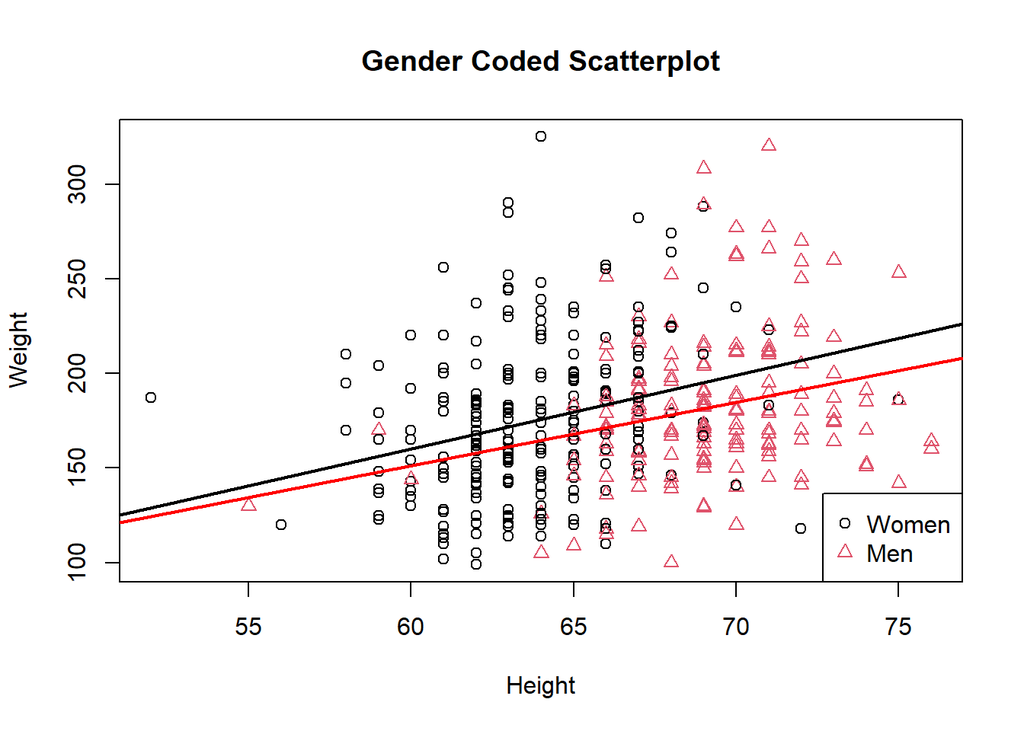

```r
af <- weight.fit.inter$coefficients[1]
am <- weight.fit.inter$coefficients[1]+weight.fit.inter$coefficients[3]
bf <- weight.fit.inter$coefficients[2]
bm <- weight.fit.inter$coefficients[2]+weight.fit.inter$coefficients[4]

plot(diabetes$height,diabetes$weight,pch=as.integer(diabetes$gender),
      col=as.integer(diabetes$gender),main='Gender Coded Scatterplot',
        ylab='Weight',xlab='Height')
legend('bottomright',legend=c('Women','Men'),
        pch=c(1,2),col=c(1,2)) # add a legend
abline(af,bf,col=1,lwd=2)
abline(am,bm,col='red',lwd=2)
```

In this case, the interaction model leads to a similar fit as the first-order model.

## Polynomial Regression

Let’s focus on using the quantitative variables `waist`, `hip`, `height`, `age` to predict `weight`.

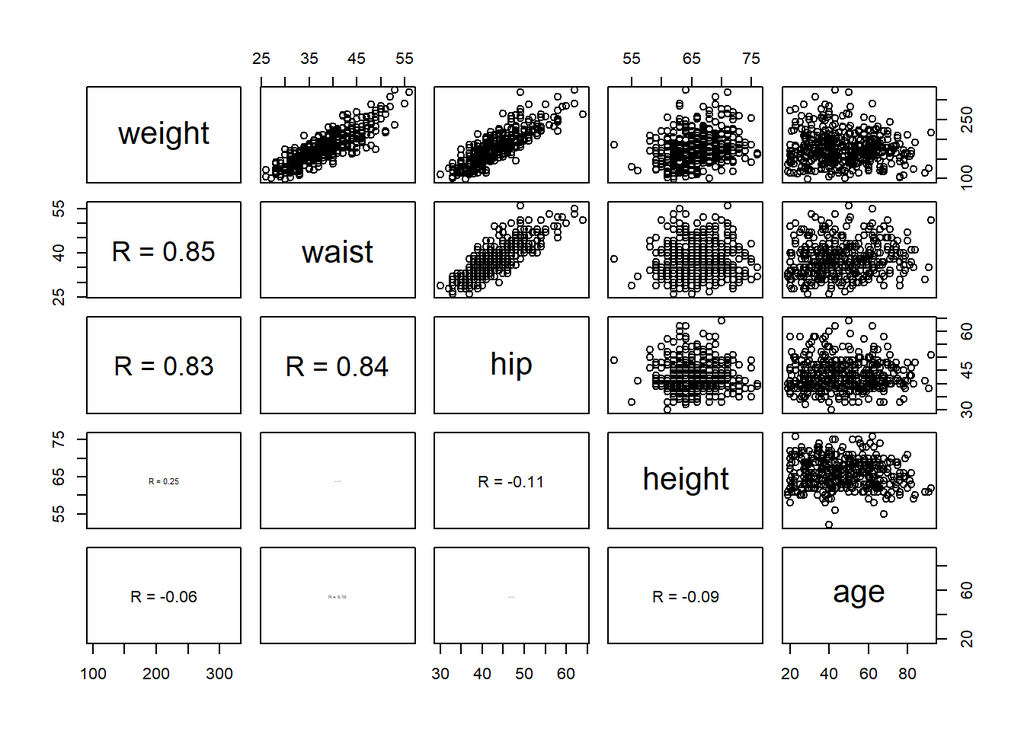

```r
panel.cor <- function(x, y) {
    # usr <- par('usr') on.exit(par(usr))
    par(usr = c(0, 1, 0, 1))
    r <- round(cor(x, y, use = "complete.obs"), 2)
    txt <- paste0("R = ", r)
    cex.cor <- 0.8/strwidth(txt)
    text(0.5, 0.5, txt, cex = cex.cor * r)
}

pairs(~weight + waist + hip + height + age, data = diabetes, lower.panel = panel.cor)
```

We can see that these relationships are fairly linear, so a linear regression model might be a good fit. Let’s first center the quantitative predictors to reduce correlation between $X$ and $X^2$ (alternatively, we could use the `scale` function to standardize the predictors):

```r
center <- function(x) {
    x - mean(x, na.rm = TRUE)
}
diabetes.c <- diabetes[, c("weight", "waist", "hip", "height", "age")]
diabetes.c[-1] <- lapply(diabetes.c[-1], center)
str(diabetes.c)
```

```
## 'data.frame':    403 obs. of  5 variables:
##  $ weight: int  121 218 256 119 183 190 191 170 166 202 ...
##  $ waist : num  -8.9 8.1 11.1 -4.9 6.1 ...
##  $ hip   : num  -5.04 4.96 13.96 -5.04 -2.04 ...
##  $ height: num  -4.02 -2.02 -5.02 0.98 1.98 ...
##  $ age   : num  -0.851 -17.851 11.149 20.149 17.149 ...
```

First consider the **first-order model**:

```r
fit1=lm(weight~., data=diabetes.c)
summary(fit1)
```

```
##
## Call:
## lm(formula = weight ~ ., data = diabetes.c)
##
## Residuals:
##     Min      1Q  Median      3Q     Max
## -45.719  -9.180  -0.435   9.407  51.573
##
## Coefficients:
##              Estimate Std. Error t value Pr(>|t|)
## (Intercept) 177.82725    0.77639 229.043  < 2e-16 ***
## waist         3.16324    0.26886  11.765  < 2e-16 ***
## hip           3.45145    0.27126  12.724  < 2e-16 ***
## height        2.73584    0.20967  13.048  < 2e-16 ***
## age          -0.26983    0.04987  -5.411  1.1e-07 ***
## ---
## Signif. codes:  0 '***' 0.001 '**' 0.01 '*' 0.05 '.' 0.1 ' ' 1
##
## Residual standard error: 15.43 on 390 degrees of freedom
##   (8 observations deleted due to missingness)
## Multiple R-squared:  0.8557, Adjusted R-squared:  0.8542
## F-statistic: 578.1 on 4 and 390 DF,  p-value: < 2.2e-16
```

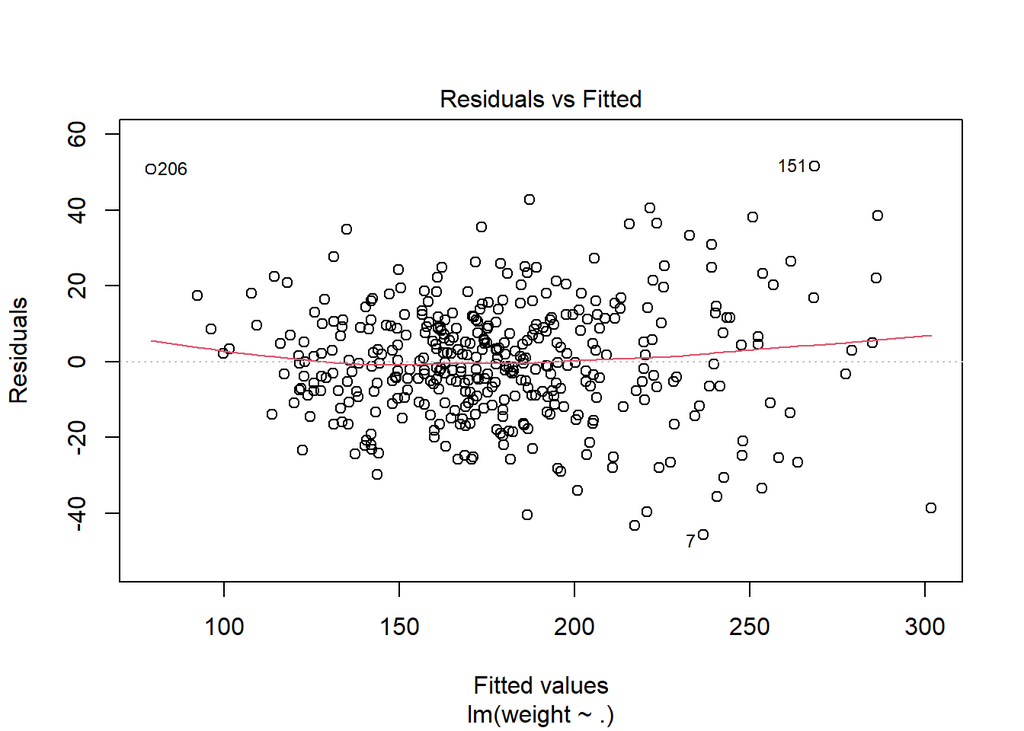

```r
plot(fit1, which=1)
```

The residual against fitted value plot above for *fit1* shows a slight quadratic trend which suggests that we may include polynomial terms in the model. It is reasonable since *weight* is proportional to the volume which is a 3-dimensional measure, while *waist*, *hip* and *height* are all 1-dimensional measures.

Now let’s fit a **second-order polynomial model**:

```r
fit2 <- lm(weight ~ waist + I(waist^2) + hip + I(hip^2) + height + I(height^2) +
    age + I(age^2) + waist:hip + waist:height + waist:age + hip:height + hip:age +
    height:age, data = diabetes.c)
summary(fit2)
```

```
##
## Call:
## lm(formula = weight ~ waist + I(waist^2) + hip + I(hip^2) + height +
##     I(height^2) + age + I(age^2) + waist:hip + waist:height +
##     waist:age + hip:height + hip:age + height:age, data = diabetes.c)
##
## Residuals:
##     Min      1Q  Median      3Q     Max
## -51.812  -8.540   0.382   9.120  40.133
##
## Coefficients:
##                Estimate Std. Error t value Pr(>|t|)
## (Intercept)  177.865176   1.333620 133.370  < 2e-16 ***
## waist          3.189804   0.272925  11.687  < 2e-16 ***
## I(waist^2)    -0.035687   0.056228  -0.635 0.526023
## hip            3.317228   0.287358  11.544  < 2e-16 ***
## I(hip^2)      -0.025033   0.062283  -0.402 0.687969
## height         2.788867   0.205786  13.552  < 2e-16 ***
## I(height^2)    0.013067   0.038767   0.337 0.736258
## age           -0.253671   0.049826  -5.091 5.61e-07 ***
## I(age^2)      -0.007728   0.002701  -2.861 0.004458 **
## waist:hip      0.075742   0.112180   0.675 0.499967
## waist:height   0.437293   0.079386   5.508 6.68e-08 ***
## waist:age      0.009872   0.017486   0.565 0.572688
## hip:height    -0.331629   0.078257  -4.238 2.84e-05 ***
## hip:age       -0.019111   0.017841  -1.071 0.284752
## height:age    -0.053405   0.013993  -3.817 0.000158 ***
## ---
## Signif. codes:  0 '***' 0.001 '**' 0.01 '*' 0.05 '.' 0.1 ' ' 1
##
## Residual standard error: 14.57 on 380 degrees of freedom
##   (8 observations deleted due to missingness)
## Multiple R-squared:  0.8746, Adjusted R-squared:   0.87
## F-statistic: 189.4 on 14 and 380 DF,  p-value: < 2.2e-16
```

Now do diagnostics again and compare `fit2` to `fit1`:

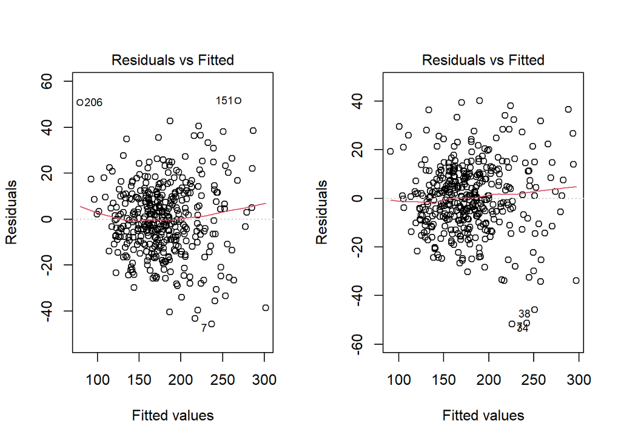

```r
par(mfrow = c(1, 2))
plot(fit1, which = 1)
plot(fit2, which = 1)
```

```r
par(mfrow = c(1, 1))
```

The polynomial model appears to fit the data slightly better than the first-order model.

In contrast, a **two-way interaction model** would look like:

```r
fit3 = lm(weight~.^2, data=diabetes.c)###see the notation
summary(fit3)
```

```
##
## Call:
## lm(formula = weight ~ .^2, data = diabetes.c)
##
## Residuals:
##     Min      1Q  Median      3Q     Max
## -52.262  -8.370  -0.428   9.606  41.041
##
## Coefficients:
##                Estimate Std. Error t value Pr(>|t|)
## (Intercept)  175.979146   0.974192 180.641  < 2e-16 ***
## waist          3.112113   0.259298  12.002  < 2e-16 ***
## hip            3.387936   0.272301  12.442  < 2e-16 ***
## height         2.875646   0.204463  14.064  < 2e-16 ***
## age           -0.278720   0.048927  -5.697 2.43e-08 ***
## waist:hip      0.016304   0.018647   0.874  0.38247
## waist:height   0.414445   0.066641   6.219 1.31e-09 ***
## waist:age     -0.006741   0.014721  -0.458  0.64728
## hip:height    -0.322049   0.067945  -4.740 3.02e-06 ***
## hip:age       -0.005469   0.015722  -0.348  0.72812
## height:age    -0.041373   0.012804  -3.231  0.00134 **
## ---
## Signif. codes:  0 '***' 0.001 '**' 0.01 '*' 0.05 '.' 0.1 ' ' 1
##
## Residual standard error: 14.65 on 384 degrees of freedom
##   (8 observations deleted due to missingness)
## Multiple R-squared:  0.8718, Adjusted R-squared:  0.8685
## F-statistic: 261.2 on 10 and 384 DF,  p-value: < 2.2e-16
```

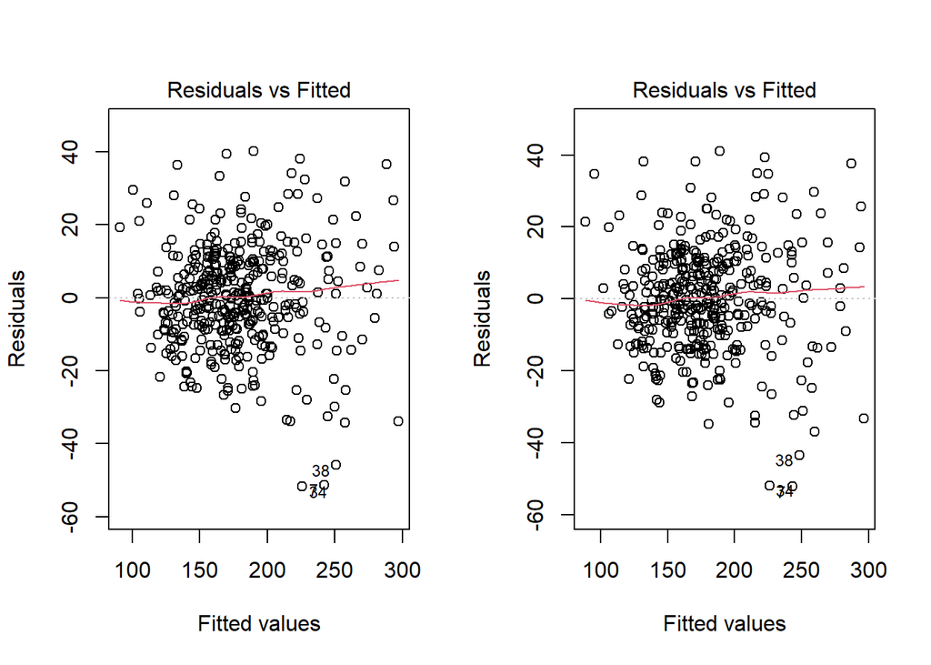

```r
par(mfrow = c(1,2))
plot(fit2,which=1)
plot(fit3, which=1)
```

```r
par(mfrow = c(1,1))
```

The results of these two models appear to be similar.

**Question**: How does the two-way interaction model differ from the second-order polynomial model?

Note that, the three models are nested. We can use the `anova` function to **compare nested models**:

```r
anova(fit1,fit3,fit2)
```

```
## Analysis of Variance Table
##
## Model 1: weight ~ waist + hip + height + age
## Model 2: weight ~ (waist + hip + height + age)^2
## Model 3: weight ~ waist + I(waist^2) + hip + I(hip^2) + height + I(height^2) +
##     age + I(age^2) + waist:hip + waist:height + waist:age + hip:height +
##     hip:age + height:age
##   Res.Df   RSS Df Sum of Sq      F    Pr(>F)
## 1    390 92855
## 2    384 82469  6   10386.3 8.1561 2.613e-08 ***
## 3    380 80651  4    1817.7 2.1411   0.07514 .
## ---
## Signif. codes:  0 '***' 0.001 '**' 0.01 '*' 0.05 '.' 0.1 ' ' 1
```

The results show that the two-way interaction model is significant compared to the first-order model, whereas the 2nd-order polynomial model is not significant compared to the two-way interaction model at level $0.05$.

## Broken-stick Regression

Sometimes, the data appears to be piecewise linear over the range of X values. In this case, we can fit a broken stick regression. In this case, separate regression lines are fitted for each interval with their end points connected. The overall line looks like a broken stick and hence the name.

Consider the following data:

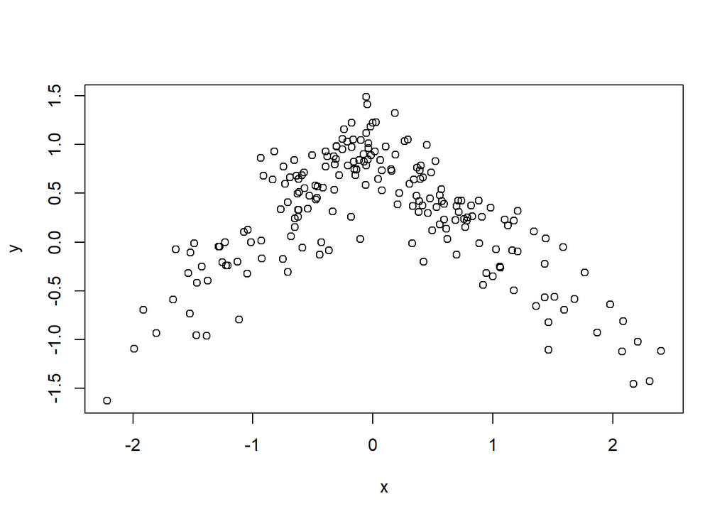

```r
load("broken_stick_example.Rdata")

plot(x,y)
```

Let us first fit a simple regression model to it and look into the diagnostics:

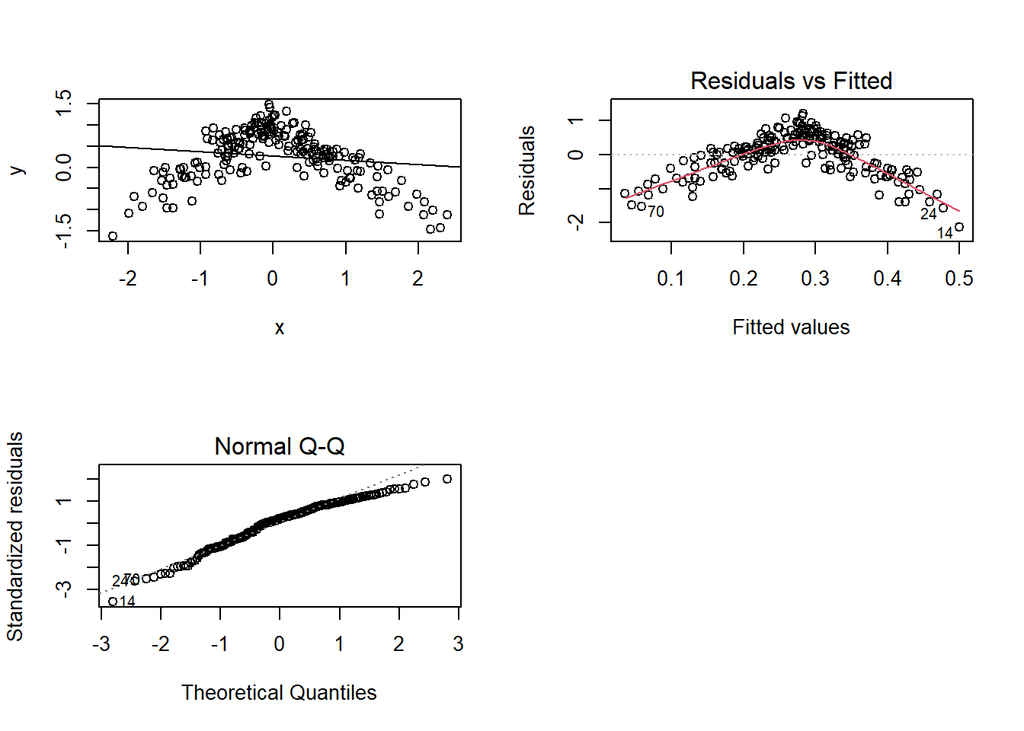

```r
fit1 <- lm(y ~ x)
par(mfrow = c(2, 2))
plot(x, y)
abline(fit1$coefficients)
plot(fit1, which = 1)
plot(fit1, which = 2)
par(mfrow = c(1, 1))
```

Clearly, the fitted regression line does not fit the data. The residual versus fitted value plot also shows a clear pattern of piecewise linear relationship. In this case, the *breakpoint* (or *knot*) is around $x=0$. For negative x-values, there is a positive slope; and for positive x-values, there is a negative slope. This is how the **broken-stick model with two segments (i.e., one breakpoint)** can be fitted:

```r
knot <- 0
x1 <- x
x2 <- (x - knot) * (x > knot)  ###x-values less than the knot are converted to 0
fit <- lm(y ~ x1 + x2)
summary(fit)
```

```
##
## Call:
## lm(formula = y ~ x1 + x2)
##
## Residuals:
##      Min       1Q   Median       3Q      Max
## -0.84674 -0.16632 -0.00304  0.20732  0.76066
##
## Coefficients:
##             Estimate Std. Error t value Pr(>|t|)
## (Intercept)  0.97339    0.03566   27.29   <2e-16 ***
## x1           0.93502    0.04826   19.37   <2e-16 ***
## x2          -1.89383    0.07745  -24.45   <2e-16 ***
## ---
## Signif. codes:  0 '***' 0.001 '**' 0.01 '*' 0.05 '.' 0.1 ' ' 1
##
## Residual standard error: 0.3032 on 197 degrees of freedom
## Multiple R-squared:  0.7579, Adjusted R-squared:  0.7555
## F-statistic: 308.4 on 2 and 197 DF,  p-value: < 2.2e-16
```

Here, both `x1` and `x2` are significant. Let’s look into the diagnostics now:

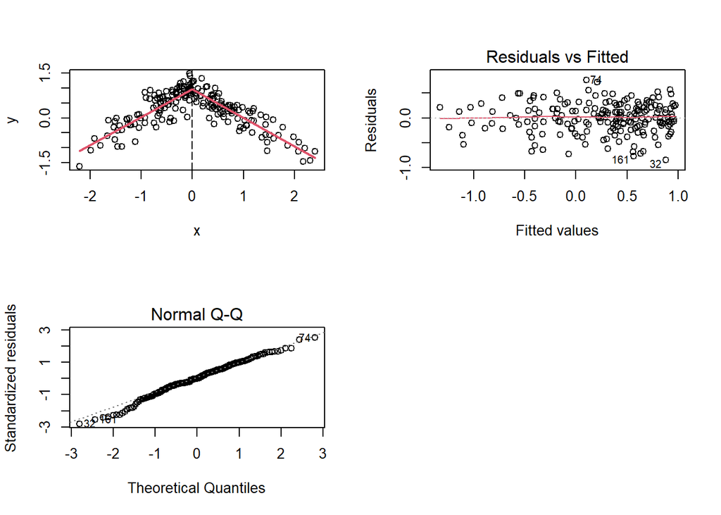

```r
par(mfrow = c(2, 2))
plot(x, y)
abline(v = knot, lty = 5)
segments(x0 = min(x1), y0 = fit$coefficients[1] + fit$coefficients[2] * min(x1),
    x1 = knot, y1 = fit$coefficients[1] + fit$coefficients[2] * knot, lwd = 2, col = 2)
segments(x0 = knot, y0 = fit$coefficients[1] + fit$coefficients[2] * knot, x1 = max(x1),
    y1 = fit$coefficients[1] + fit$coefficients[2] * max(x1) + fit$coefficients[3] *
        (max(x1) - knot), lwd = 2, col = 2)

plot(fit, which = 1)
plot(fit, which = 2)
par(mfrow = c(1, 1))
```

This model is obviously a better fit than the previous model. The residual plots no longer show any particular pattern.